# Comprehensive Manual for SUV Computation and Digital Reference Objects for its Verification

Working version 3.1

Michael Vácha <sup>1,2,3</sup>, The Image Biomarker Standardisation Initiative (IBSI) $, Frank Hofheinz <sup>3</sup>, Anja Braune <sup>3,4</sup>, Steffen Löck <sup>1,2,5,6,7</sup>, Alex Zwanenburg <sup>1,5</sup>

<sup>1</sup>OncoRay-National Center for Radiation Research in Oncology, Faculty of Medicine and University Hospital Carl Gustav Carus, Technische Universität Dresden, Helmholtz-Zentrum Dresden-Rossendorf, Dresden, Germany

<sup>2</sup>Helmholtz-Zentrum Dresden-Rossendorf, Institute of Radiooncology - OncoRay, Dresden, Germany

<sup>3</sup>Institute of Radiopharmaceutical Cancer Research, Helmholtz-Zentrum Dresden-Rossendorf, Dresden, Germany

<sup>4</sup>Department of Nuclear Medicine, University Hospital Carl Gustav Carus, Technische Universität Dresden, Dresden, Germany

<sup>5</sup>National Center for Tumor Diseases (NCT), NCT/UCC Dresden, a partnership between DKFZ, Faculty of Medicine and University Hospital Carl Gustav Carus, TUD Dresden University of Technology, and Helmholtz-Zentrum Dresden-Rossendorf (HZDR), Germany

<sup>6</sup>Department of Radiotherapy and Radiation Oncology, Faculty of Medicine and University Hospital Carl Gustav Carus, Technische Universität Dresden, Dresden, Germany

<sup>7</sup>German Cancer Consortium, partner site Dresden, and German Cancer Research Center, Heidelberg, Germany

$ Participants and their affiliations are to be specified.

# Introduction

There is an [increasing interest](https://www.frontiersin.org/journals/oncology/articles/10.3389/fonc.2022.965773/full) in using positron emission tomography (PET) data for segmentation, biomarker identification, and outcome prediction. To make PET values comparable between patients, these values are often normalized to a standard unit, which is, in most cases, the body-weight-normalized standardized uptake value (SUV<sub>bw</sub>). By definition, the SUV<sub>bw</sub> can be computed from the formula:

$$\text{SUV}_{\mathrm{bw}} =
\frac{\scriptstyle A_c \, W}{\scriptstyle D}$$

where ${A}_{c}$ represents the measured activity concentration within a region of interest or voxel in Bq/ml, $W$ the weight of the patient in g, and $D$ the total administered radionuclide dose at the time to which the voxel values correspond, in Bq. However, PET imaging data in Digital Imaging and Communications in Medicine (DICOM) files are not stored as standardized uptake values. Consequently, the voxel values and associated metadata have to be correctly interpreted by medical image analysis software in order to convert the stored voxel values to SUV<sub>bw</sub>. In the radiomics field, many tools were not primarily designed for PET imaging and may not process all relevant metadata correctly. Consequently, identical images may be processed inconsistently across various tools. This can give rise to two potential issues:

- incorrect or inconsistent SUV<sub>bw</sub> calculation, resulting in under- or overestimation of SUV<sub>bw</sub> values, which may introduce unrecognized bias and reduce generalizability;
- errors that lead to patient exclusion and a decreased sample size.

By creating reference standards for SUV<sub>bw</sub> computation, we aim to:

- verify that SUV<sub>bw</sub> is computed correctly;
- maximize the number of PET imaging series eligible for quantitative image analysis.

Therefore, we:

1. studied how clinical PET images are stored within DICOM files;
2. summarized the instructions on how to interpret these files to calculate SUV<sub>bw</sub> correctly;
3. generated a set of representative digital reference objects (DROs) to assess whether imaging software can accurately interpret diverse PET DICOM formats.

# Methods

## Metadata analysis

To analyze how PET imaging data are stored, we searched for real-world PET human imaging series via two sources:

- our internal imaging archives
- The Cancer Imaging Archive Radiology Portal, where we identified 34 cohorts containing relevant PET imaging data: [ACRIN-FLT-Breast](https://doi.org/10.7937/K9/TCIA.2017.ol20zmxg), [ACRIN-NSCLC-FDG-PET](https://doi.org/10.7937/tcia.2019.30ilqfcl), [Anti-PD-1_Lung](https://doi.org/10.7937/tcia.2019.zjjwb9ip), [BREAST-DIAGNOSIS](http://doi.org/10.7937/K9/TCIA.2015.SDNRQXXR), [CC-Tumor-Heterogeneity](https://doi.org/10.7937/ERZ5-QZ59), [CMB-CRC](https://doi.org/10.7937/DJG7-GZ87), [CMB-GEC](https://doi.org/10.7937/E7KH-R486), [CMB-LCA](https://doi.org/10.7937/3CX3-S132), [CMB-MEL](https://doi.org/10.7937/GWSP-WH72), [CMB-MML](https://doi.org/10.7937/SZKB-SW39), [CMB-PCA](https://doi.org/10.7937/25T7-6Y12), [CPTAC-CM](https://doi.org/810.7937/K9/TCIA.2018.ODU24GZE), [CPTAC-HNSCC](https://doi.org/10.7937/K9/TCIA.2018.UW45NH81), [CPTAC-LSCC](https://doi.org/10.7937/K9/TCIA.2018.6EMUB5L2), [CPTAC-LUAD](https://doi.org/10.7937/K9/TCIA.2018.PAT12TBS), [CPTAC-PDA](https://doi.org/10.7937/K9/TCIA.2018.SC20FO18), [CPTAC-SAR](https://doi.org/10.7937/tcia.2019.9bt23r95), [CPTAC-UCEC](https://doi.org/10.7937/K9/TCIA.2018.3R3JUISW), [FDG-PET-CT-Lesions](https://doi.org/10.7937/gkr0-xv29), [Head-Neck-PET-CT](https://doi.org/10.7937/K9/TCIA.2017.8oje5q00), [Lung-PET-CT-Dx](https://doi.org/10.7937/TCIA.2020.NNC2-0461), [NaF PROSTATE](https://doi.org/10.7937/K9/TCIA.2015.ISOQTHKO), [NSCLC Radiogenomics](https://doi.org/10.7937/K9/TCIA.2017.7hs46erv), [QIN-BREAST](https://doi.org/10.7937/K9/TCIA.2016.21JUEBH0), [RIDER Lung PET-CT](https://doi.org/10.7937/k9/tcia.2015.ofip7tvm), [Soft-tissue-Sarcoma](http://doi.org/10.7937/K9/TCIA.2015.7GO2GSKS), [TCGA-BLCA](https://doi.org/10.7937/K9/TCIA.2016.8LNG8XDR), [TCGA-KIRP](https://doi.org/10.7937/K9/TCIA.2016.ACWOGBEF), [TCGA-LUAD](https://doi.org/10.7937/K9/TCIA.2016.JGNIHEP5), [TCGA-LUSC](https://doi.org/10.7937/K9/TCIA.2016.TYGKKFMQ), [TCGA-PRAD](https://doi.org/10.7937/K9/TCIA.2016.YXOGLM4Y), [TCGA-THCA](https://doi.org/10.7937/K9/TCIA.2016.9ZFRVF1B), [TCGA-UCEC](https://doi.org/10.7937/K9/TCIA.2016.GKJ0ZWAC), and [VAREPOP-APOLLO](https://doi.org/10.7937/ghkn-md15).

We excluded imaging series without attenuation correction and detector normalization applied, as well as series with only one frame within, maximum intensity projections and other reprojections. For all remaining series, we scanned a set of relevant attributes (listed in Supplementary Table 1) and analyzed how they were used in practice. When applicable, a tolerance of ±1.0 s was applied to disregard mismatches attributable to rounding errors.

## Manual for SUV computation

Based on the literature ([DICOM standards](https://www.dicomstandard.org/), [QIBA consensus](https://qibawiki.rsna.org/index.php/Main_Page), [Turku PET center manual](http://www.turkupetcentre.net/petanalysis/index.html), [USZ technical note](https://arxiv.org/pdf/2410.13348)), our expertise, and the metadata analysis, we summarized the rules for computing SUV<sub>bw</sub> within DICOM PET images. The recommendations apply to clinical PET images belonging to the Positron Emission Tomography Service-Object Pair (SOP) Class, i.e., series with a SOP Class UID (0008,0016) value “1.2.840.10008.5.1.4.1.1.128”. Recommendations for other SUV types and other SOP classes, including the Enhanced PET SOP class, are summarized at the end of the Results section. Supplementary Figures 1 and 2 summarize the recommended strategy for the Positron Emission Tomography SOP class and the Enhanced PET SOP class, respectively. Supplementary Tables 2 and 3 list all DICOM attributes required for SUV<sub>bw</sub> computation in images from these two SOP classes.

## Construction of digital reference objects

Furthermore, we assembled a comprehensive set of digital reference objects (DROs) for verifying SUV computation. All DRO DICOM files were synthesized de novo using the Python [pydicom](https://doi.org/10.5281/zenodo.13824606) library version 3.0.1. The design of these DROs was chosen to resemble common PET calibration phantoms – each DRO includes one hot sphere (SUV<sub>bw</sub> = 4.00), one cold sphere (SUV<sub>bw</sub> = 0.20), a background region (SUV<sub>bw</sub> = 1.00), and a surrounding zero-activity region (SUV<sub>bw</sub> = 0.00) (See Figure 1).

All DROs are identical in terms of the design, volumes, and resulting SUV<sub>bw</sub> values, while the stored voxel values and DICOM attributes vary based on the intended use of each DRO. The region of interest (ROI) for SUV evaluation covers the whole DRO volume, excluding the surrounding region. For the sake of compatibility, it is provided in two formats: as a binary NIfTI (Neuroimaging Informatics Technology Initiative) mask and as a radiotherapy structure set (RTSTRUCT) containing one 3D contour.

To verify that a software tool computes the SUV<sub>bw</sub> correctly, the operator is supposed to either:

1. directly compute SUV<sub>bw_max</sub>, SUV<sub>bw_min</sub>, and SUV<sub>bw_med</sub> from the maximum, minimum, and median voxel value within the ROI;
2. convert the DRO DICOM file to SUV<sub>bw</sub> units and extract the maximum, minimum, and median SUV<sub>bw</sub> within the ROI;
3. convert the DRO DICOM file to SUV<sub>bw</sub> and visually inspect the values in the hot sphere, cold sphere, and background region.

All computed values should be rounded to two decimal places. The target values are identical across all cases and are defined as follows:

- Hot sphere / maximum DRO value = 4.00 SUV<sub>bw</sub>
- Cold sphere / minimum DRO value = 0.20 SUV<sub>bw</sub>
- Background region / median DRO value = 1.00 SUV<sub>bw</sub>

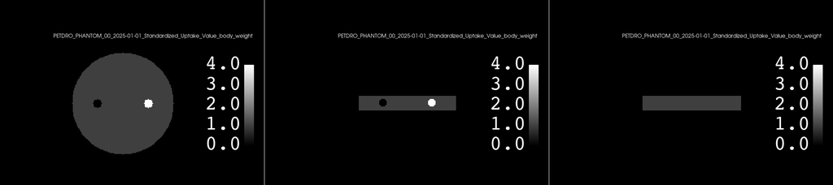

Fig. 1: Visualization of the DRO design in axial, coronal, and sagittal planes (from left to right). Voxel values are shown in SUV<sub>bw</sub>.

## Real-world dataset

A representative set of real-world PET imaging series was collected to verify that different implementations lead to identical SUVs within clinical data. For each series, a ROI was generated using [LIFEx v25.06.1](https://doi.org/10.1158/0008-5472.CAN‑18‑0125) and for compatibility purposes, the headers were edited using [SimpleITK](https://doi.org/10.3389/fninf.2013.00045).

# Results

## Baseline characteristics

For the metadata analysis, we identified and examined 3722 PET imaging series from 2589 patients. These images were acquired by a large variety of PET scanner models, with the majority (93.8%) from three PET scanner vendors: 1757 (47.2 %) series were from Siemens (Siemens Healthineers, Erlangen, Germany), 1365 (36.7 %) from GE (GE HealthCare, Chicago, USA) and 371 (10.0 %) from Philips (Philips Healthcare, Amsterdam, Netherlands). The remaining series were from CTI/CPS (CTI Molecular Imaging/CPS Innovations, Knoxville, USA) or the Manufacturer (0008,0070) attribute did not contain any name of a PET scanner vendor (Table 1).

Table 1: Percentage of series and a list of unique Manufacturer Model Name (0008,1090) values by scanner vendor.

| Manufacturer | Perc | Models |
| --- | --- | --- |
| CTI/CPS | 5.1 % | 1023, 1024, 1062, 1080, 962 |
| GE | 36.7 % | Advance, Discovery 610, Discovery 690, Discovery 710, Discovery IQ, Discovery LS, Discovery MI, Discovery MI DR, Discovery RX, Discovery ST, Discovery STE |
| Philips | 10.0 % | Allegro Body(C), GEMINI TF Big Bore, GEMINI TF TOF 16, Guardian Body(C), TruFlight Select |
| Siemens | 47.2 % | 1080, 1093, 1094, Biograph 20_mCT, Biograph 64_mCT, Biograph Horizon, Biograph128, Biograph128_mCT, Biograph128_mCT 4R, Biograph128_Vision 450 Edge, Biograph16_Horizon 3R, Biograph20_mCT, Biograph20_m… |
| Unknown | 1.0 % | DicomCleaner, Integrity Medical Image Importer |

## Rescale slope and intercept

#### Background

The attribute Pixel Data (7fe0,0010) stores the voxel values. As for other imaging modalities, the Pixel Data attribute can be read using other attributes from the DICOM Image Pixel Module, such as Rows (0028,0010), Columns (0028,0011), Bits Allocated (0028,0100), or Pixel Representation (0028,0103).

Due to the wide range of the real-world values in PET imaging data, the use of Rescale Slope (0028,1053) and Intercept (0028,1052) ensures that stored values are within the range that can be stored in the voxel data type (e.g., signed 16-bit integers can store integer values from -32,768 to 32,767). The rescale intercept is required to be zero in all PET studies of the Positron Emission Tomography SOP Class; however, this rule was dropped in other PET SOP classes. Applying the rescale slope and intercept to the stored voxel values leads to their conversion to the real-world values, with a unit specified in Units (0054,1001). Independent of the units, it is a mandatory first step in SUV<sub>bw</sub> calculation:

$$\text{U} = {m \, SV + b}$$

where U are the real-world values, SV are the stored voxel values (Pixel Data; 7fe0,0010), m the rescale slope, and b the rescale intercept (Rescale Intercept; 0028,1052). The rescale slope and intercept may vary for each frame and must be applied on a frame-wise basis.

#### Metadata analysis

Comparing series, a wide range of rescale slopes was observed in the studied data. In general, the rescale slope values within each series were either:

- constant (N = 1086, 29.2 %)
- different in each frame (N = 2090, 56.2 %)
- rather constant with a few exceptions (N = 544, 14.6 %) - we noted the exceptions typically included frames with the highest uptake (e.g., slices containing the tumor region).

In our dataset, all PET imaging series had Rescale Intercept and Rescale Slope attributes present. The value of Rescale Intercept was always zero. The Rescale Slope always had a positive value.

#### Digital reference object

The following DRO was constructed:

- DRO_1_0 containing multiple values of the Rescale Slope attribute. Potential problems are:
  - Rescale Slope is not applied frame-wise

#### Recommendations

*The Rescale Slope (0028,1053) attribute must be present and not empty. The operator should receive a warning when a non-positive value is present.*

*The Rescale Intercept (0028,1052) attribute must be present and not empty. The operator should receive a warning when a non-zero value is present.*

*The corresponding Rescale Slope (0028,1053) and Rescale Intercept (0028,1052) have to be applied to all stored voxel values (Pixel Data; 7fe0,0010) within a frame, independently of other parameters.*

Justification: The Rescale Slope and Rescale Intercept are required in PET images to convert stored voxel values to real-world values and may vary between frames. The Rescale Intercept is required to be zero in PET images of the Positron Emission Tomography SOP Class. Other values indicate non-standard rescaling within image post-processing, and such images should be interpreted with caution. The Rescale Slope is typically positive. A Rescale Slope value of zero may be observed in marginal slices.

## Units

#### Background

As mentioned before, the attribute specifies to which units the stored voxel values are converted by applying the rescale slope and intercept. In general, the strategy can be divided into two pathways:

1. direct conversion of stored voxel values to SUV<sub>bw</sub>;
2. conversion of stored voxel values to Bq/ml followed by conversion to SUV<sub>bw</sub>.

##### Units = “BQML”

The attribute Units (0054,1001) is commonly set to “BQML”, which signals real-world value unit becquerels per milliliter. Assuming W and D are properly corrected and expressed in the right units, U may be used directly in the formula:

$$\text{SUV}_{\mathrm{bw}} =
\frac{\scriptstyle U \, W}{\scriptstyle D}$$

However, real-world values may have other units based on the scanner’s protocol or due to DICOM file post-processing.

##### Units = “GML”

Another common value of the Units (0054,1001) attribute is grams per milliliter (“GML”). This indicates the activity concentration was already normalized. In most cases, it corresponds to body-weight normalization (BW), where SUV<sub>bw</sub> equals the real-world value of the voxel.

$$\text{SUV}_{\mathrm{bw}} =
U$$

However, there may be scenarios where other normalization techniques were applied. Specifically, four other SUV methods are compliant with the current [DICOM standard](https://www.dicomstandard.org/) and result in the unit GML. The method used can be extracted from the attribute SUV Type (0054,1006) and should be considered body weight if unspecified or when the value is “BW”. The following factors are used, as reported by [Sugawara](https://doi.org/10.1148/radiology.213.2.r99nv37521):

- lean body mass by [Morgan](https://link.springer.com/article/10.2165/00003088-199426040-00005) (SUV Type = “LBM”)

  for male patients: $\text{LBM} = 1.10 W - 120 ({\scriptstyle \frac{W}{H}})^2$

  for female patients: $\text{LBM} = 1.07 W - 148 ({\scriptstyle \frac{W}{H}})^2$
- lean body mass by James et al. (James, William Philip Trehearne, and J. C. Waterlow. Research on obesity. 1976) / [Morgan](https://link.springer.com/article/10.2165/00003088-199426040-00005) (SUV Type = “LBMJAMES128”)

  for male patients: $\text{LBM}_{james128} = 1.10 W - 128 ({\scriptstyle \frac{W}{H}})^2$

  for female patients: $\text{LBM}_{james128} = 1.07 W - 148 ({\scriptstyle \frac{W}{H}})^2$
- lean body mass by [Janmahasatian](https://doi.org/10.2165/00003088-200544100-00004) (SUV Type = “LBMJANMA”)

  $\text{BMI} = \scriptstyle \frac{W}{(H \, 10^{-2})^2}$

  for male patients: $\text{LBM}_{janma} = \scriptstyle \frac{9270 W}{6680 + 216 \text{BMI}}$

  for female patients: $\text{LBM}_{janma} = \scriptstyle \frac{9270 W}{8780 + 244 \text{BMI}}$
- ideal body weight (SUV Type = “IBW”)

  for male patients: $\text{IBW} = 48.0 + 1.06 (H - 152)$

  for female patients: $\text{IBW} = 45.5 + 0.91 (H - 152)$

For all formulas, W is weight in kg, and H is height in cm. Additionally, the following attributes are required:

- Patient’s Size (0010,1020) - Height of the patient in m;
- Patient’s Sex (0010,0040) - Sex of the patient with possible values “M” (male), “F” (female) or “O” (other).

In turn, this factor (LBM, LBM<sub>james128</sub>, LBM<sub>janma</sub>, or IBW) can be used for normalization:

$$\text{SUV}_{\mathrm{factor}} =
\frac{\scriptstyle A_c \, \text{factor} \, 10^{3}}{\scriptstyle
D}$$

To get the SUV<sub>bw</sub> values, the real-world values can be multiplied by the patient’s weight and divided by the corresponding factor:

$$\text{SUV}_{bw} = \frac{\scriptstyle
U \, W}{\scriptstyle \text{factor} \, 10^{3}}$$

There is currently no consensus on the computation of LBM and IBW when Patient’s Sex is specified as “O”. Using the mean value of the sex-specific factors appears to be a reasonable and simple solution.

##### Units = “CM2ML”

The unit square centimeters per milliliter (Units = “CM2ML”) corresponds to images normalized to body surface area (BSA) using the [Du Bois formula](https://pubmed.ncbi.nlm.nih.gov/2520314/):

$$\text{BSA} = 0.007184 \, H^{0.725} \,
W^{0.425}$$

where H is height in cm, and W is weight in kg. The SUV Type (0054,1006) should be set to “BSA” in this case. SUV<sub>bsa</sub> is calculated as:

$$\text{SUV}_{\mathrm{bsa}} =
\frac{\scriptstyle A_c \, \text{BSA} \, 10^{4}}{\scriptstyle
D}$$

SUV<sub>bw</sub> can be back-computed analogically to the previous section:

$$\text{SUV}_{bw} = \frac{\scriptstyle U
\, W}{\scriptstyle \text{BSA} \, 10^{4}}$$

##### Units = “CNTS”

Philips scanners often use the unit counts (Units = “CNTS”). In this case, scale factors must be provided for converting the stored voxel values. SUV scale factor allows direct conversion of the real-world values to SUV<sub>bw</sub>.  
The formula is mentioned in Philips’ conformance statements (here, for [Philips Ingenuity](https://www.documents.philips.com/doclib/enc/fetch/2000/4504/577242/577256/588723/5144873/5144488/5144390/DICOM_Conformance_statement_forIngenuity_TF_PET_CT.pdf)):

*(7053,1000) DS SUV Scale Factor: This value only applies when Units (0054,1001) is equal to CNTS. The SUV Scale Factor is used to convert the voxel data from counts to an SUV value. This is done by using the formula SUV Value = ((SV x m) + b) x f, where: SV = original stored voxel value, m = Rescale Slope (0028,1053), b = Rescale Intercept (0028,1052), f = SUV Scale Factor (7053, 1000). If the SUV Scale Factor is 0.0, then the voxel data cannot be converted from counts to an SUV value.*

The Activity Concentration Scale Factor allows the conversion of the real-world values to Bq/ml, as explained in the conformance statement (here, for [Philips Ingenuity](https://www.documents.philips.com/doclib/enc/fetch/2000/4504/577242/577256/588723/5144873/5144488/5144390/DICOM_Conformance_statement_forIngenuity_TF_PET_CT.pdf)):

*(7053,1009) DS Activity Concentration Scale Factor: This value only applies when Units (0054,1001) is equal to CNTS. The Activity Concentration Scale Factor is used to convert the voxel data from counts to Activity Concentration (in Bq/ml). This is done by using the formula Activity Concentration Value = ((SV x m) + b) x f, where: SV = original stored voxel value, m = Rescale Slope (0028,1053), b = Rescale Intercept (0028,1052), f = Activity Concentration Scale Factor (7053, 1009). If the Activity Concentration Scale Factor is 0.0, then the voxel data cannot be converted from counts to Activity Concentration.*

##### Other units

For other units, the conversion to activity concentration or SUV<sub>bw</sub> is impossible or unclear.

That includes, above all, the following units:

- CPS - counts per second, conversion requires vendor- or scanner-specific factors that may not be included in the DICOM metadata
- PROPCNTS - proportional to counts, not mentioned in conformance statements, conversion is not clear
- PROPCPS - proportional to counts per second, [mentioned by Siemens](https://marketing.webassets.siemens-healthineers.com/e224b4e95f62dbd6/b4ec4dc662f0/MI_DCS_Horizon_VJ30.pdf?ste_sid=4472df6cb8103bfe5fad8589b711dce6) for “non-quantitative, non-attenuation corrected images”, the conversion is not clear
- 1CM - 1/centimeter, used for mu maps

#### Metadata analysis

In most series (93.4 %) the units were Bq/ml. Other units used were dependent on the scanner vendor (see Table 2):

Table 2: Frequency of unique Units (0054,1001) value by vendor (displayed as number of series).

|  | BQML | CNTS | CPS | GML | PROPCNTS |
| --- | --- | --- | --- | --- | --- |
| Total | 3476 | 145 | 71 | 19 | 11 |
| Siemens | 1757 | 0 | 0 | 0 | 0 |
| GE | 1274 | 0 | 71 | 9 | 11 |
| Philips | 216 | 145 | 0 | 10 | 0 |
| CTI/CPS | 191 | 0 | 0 | 0 | 0 |
| Unknown | 38 | 0 | 0 | 0 | 0 |

There were no cases with a non-NA value in the SUV Type attribute.

Regarding counts as units and their conversion, 142 series (97.9 %) with these units had at least one scale factor provided - 136 series (93.8 %) contained both factors and 6 series (4.1 %) only the SUV scale factor. The Activity Concentration Scale Factor never appeared without the SUV scale factor. 3 series (2.1 %) stored none of the factors.

Philips conformance statements do not specify which SUV type results from the application of the SUV scale factor, and none of the analyzed series contained the SUV Type (0054,1006) attribute. However, in all 136 series in which both factors were present, the SUV scale factor numerically corresponded to SUV<sub>bw</sub>. Specifically, computing SUV<sub>bw</sub> using the Activity Concentration Scale Factor and Patient’s Weight yielded practically identical SUV<sub>bw</sub> values to those obtained using the SUV scale factor (mean paired relative difference: 0.05%).

#### Digital reference object

We synthesized multiple DROs verifying a standardized computation of SUV<sub>bw</sub>:

- DRO_2_0 where Units are “GML” (corresponding to SUV<sub>bw</sub>). Potential problems are:
  - unit GML is not implemented;
  - SUV Type is required (while it should be considered “BW” by default)
  - Rescale Slope is not applied.
- DRO_2_1_x where Units are “GML” (corresponding to SUV LBMJAMES128), coming in three variations: DRO_2_1_0 (Patient’s Sex = “M”), DRO_2_1_1 (Patient’s Sex = “F”), DRO_2_1_2 (Patient’s Sex = “O”). Potential problems are:
  - SUVlbm is not implemented or an incorrect LBM formula is used (instead of LBMJAMES128);
  - SUV type, patient’s weight, height, or sex are not extracted correctly;
  - strategy for Patient’s Sex = “O” is not implemented.
- DRO_2_2_x where Units are “GML” (corresponding to SUV IBW), coming in three variations: DRO_2_2_0 (Patient’s Sex = “M”), DRO_2_2_1 (Patient’s Sex = “F”), DRO_2_2_2 (Patient’s Sex = “O”). Potential problems are:
  - SUVibw is not implemented or an incorrect formula is used;
  - SUV type, patient’s weight, height, or sex are not extracted correctly;
  - strategy for Patient’s Sex = “O” is not implemented.
- DRO_2_3 where Units are “CM2ML” (corresponding to SUVbsa). Potential problems are:
  - unit CM2ML or SUVbsa are not implemented or an incorrect formula is used;
  - SUV type, patient’s weight, or height are not extracted correctly.
- DRO_2_4 where Units are “CNTS”, with the Philips SUV scale factor present. Potential problems are:
  - unit CNTS is not implemented;
  - SUV scale factor is not extracted or applied correctly.
- DRO_2_5 where Units are “CNTS”, with the Philips activity scale factor present. Potential problems are:
  - unit CNTS is not implemented;
  - activity scale factor is not extracted or applied correctly.
- DRO_2_6_x where Units are GML (corresponding to SUV LBMJANMA), coming in three variations: DRO_2_6_0 (PatientSex = “M”), DRO_2_6_1 (PatientSex = “F”), DRO_2_6_2 (PatientSex = “O”). Potential problems are:
  - SUVlbmjanma is not implemented or an incorrect LBM formula is used (instead of LBMJANMA);
  - SUV type, patient’s weight, height, or sex are not extracted correctly;
  - strategy for Patient’s Sex = “O” is not implemented.

Note: The strategy with SUV Type = “LBM” is considered obsolete and currently not covered by the digital reference objects.

The following DROs should yield an error in SUV<sub>bw</sub> computation:

- DRO_error_2_0 where Units are “BQML” and Patient’s Weight is absent
- DRO_error_2_1 where Units are “BQML” and Patient’s Weight is zero
- DRO_error_2_2 where Units are “GML” and Patient’s Sex is absent
- DRO_error_2_3 where Units are “GML” and Patient’s Sex has other value (“X”)
- DRO_error_2_4 where Units are “GML” and Patient’s Size is absent
- DRO_error_2_5 where Units are “GML” and Patient’s Size is zero
- DRO_error_2_6 where Units are “CNTS” and none of the Philips scale factors are present
- DRO_error_2_7 where Units are “PROPCNTS”

#### Recommendations

*The Units (0054,1001) attribute must be present and have one of these values: “BQML”, “GML”, “CM2ML”, “CNTS”; otherwise, SUV<sub>bw</sub> computation is not possible.*

Justification: The conversion formula depends on Units.

*When the Units (0054,1001) are set to “GML” and the SUV Type (0054,1006) is set to “BW” or is empty or absent, the real-world values correspond to SUV<sub>bw</sub>.*

Justification: In this case, the real-world values have the unit SUV<sub>bw</sub>.

*When the Units (0054,1001) are set to “CM2ML” and the SUV Type (0054,1006) is set to “BSA”, and the Patient’s Weight (0010,1030) and the Patient’s Size (0010,1020) have a positive, non-zero value,* *the real-world values can be converted directly to SUV<sub>bw</sub> by multiplying by the Patient’s Weight (0010,1030) and dividing by the corresponding normalization factor.*

Justification: In this case, the real-world values correspond to another SUV type and have to be converted to SUV<sub>bw</sub> by the aforementioned formulas.

*When the Units (0054,1001) are set to “CNTS” and the Activity Concentration Scale Factor (7053,1009) is present and has a non-zero value, and the Manufacturer (0008,0070) attribute contains “PHILIPS”,* *the real-world values can be converted to Bq/ml by multiplying by the Activity Concentration Scale Factor (7053,1009).*

*If it is absent, empty, or zero and the SUV Scale Factor (7053,1000) is present and has a non-zero value and the Manufacturer (0008,0070) attribute contains “PHILIPS”, and the SUV Type (0054,1006) is “BW” or empty or absent,* *the real-world values can be directly converted to SUV<sub>bw</sub> by multiplying by the SUV Scale Factor (7053,1000).*

Justification: These factors are provided by Philips to allow conversion to Bq/ml and SUV<sub>bw</sub>.

*If the Units (0054,1001) are “BQML” or the values are converted to Bq/ml, conversion from Bq/ml to SUV<sub>bw</sub> is required.*

*If the Units (0054,1001) are not “BQML” and the conversion to SUV<sub>bw</sub> or Bq/ml is not possible by the aforementioned methods, SUV<sub>bw</sub> computation is not possible.*

## Patient’s weight

#### Background

Patient’s Weight (0010,1030) is often manually entered, which can result in missing values or incorrect units. The correct DICOM unit is kilograms; values equal to or greater than 1000 indicate that the weight was entered in grams. For the SUV<sub>bw</sub> formula, the value must be converted to grams. Furthermore, patient weight may occasionally be incorrectly stored in a different DICOM attribute, particularly Patient’s Size (0010,1020).

#### Metadata analysis

Out of the 3476 series where the Units were “BQML”, i.e., Patient’s Weight was required for SUV<sub>bw</sub> computation, the value of Patient’s Weight was zero in 19 (0.5 %) cases. There was no case where the value of Patient’s Weight would be negative or higher than 1000. In 32 (0.9 %) series, Patient’s Weight was empty or absent.

#### Digital reference object

There are currently no digital reference objects for Patient’s Weight.

#### Recommendations

*If conversion from Bq/ml to SUV<sub>bw</sub> is required, the attribute Patient’s Weight (0010,1030) should be checked that it is present and has a positive, non-zero value. Otherwise, SUV<sub>bw</sub> computation is not possible.*

Justification: Patient’s Weight is required for conversion to SUV<sub>bw</sub>.

*The Patient’s Weight (0010,1030) values equal to or greater than 1000 should be interpreted as grams, while values lower than 1000 should be interpreted as kilograms.*

Justification: Patient’s Weight may occasionally be stored in grams. A threshold of 1000 was selected arbitrarily, as values equal to or greater than 1000 kg or below 1000 g are highly unlikely in clinical or phantom PET imaging. Note that the SUV<sub>bw</sub> formula requires weight in grams while the aforementioned LBM/IBW/BSA formulas expect weight in kilograms.

## Radiopharmaceutical dose

#### Background

The Radionuclide Total Dose (0018,1074) DICOM field records the total administered dose of the radionuclide (within the administered radiotracer). It is another attribute that is typically recorded manually, which may result in missing values or incorrect units. Furthermore, the unit may not be standardized as different Information Object Definitions (IODs) allow either Bq or MBq. The equation expects the unit to be Bq.

For SUV<sub>bw</sub> computation - as long as conversion from Bq/ml to SUV<sub>bw</sub> is required - the administered dose must correspond to the same time point as the real-world values. To do that, it is essential to know whether the voxel values were decay-corrected and, if so, to which time point. This information is provided by the Decay Correction (0054,1102) attribute, which can take one of three predefined values (“ADMIN,” “START,” or “NONE”). As shown below, the subsequent correction steps depend on this attribute.

In this manual, we provide equations for one of the possible solutions, which is correcting the administered dose for the radioactive decay of the radionuclide between the time of administration and the corresponding decay-correction reference datetime. Other solutions would include correcting the voxel values to the administration datetime, or correcting both voxel values and dose to another time point.

SUV<sub>bw</sub> is independent of the time point to which the dose and voxel values were corrected. Therefore, the Decay Correction (0054,1102) is not relevant when Units are “GML” or “CM2ML” or when the image can be directly scaled to SUV<sub>bw</sub> without considering the administered dose (Units are “CNTS” and SUV Scale Factor (7053,1000) is applied).

##### Decay correction = ADMIN

The value “ADMIN” indicates that the PET image data were decay-corrected to the time of radiotracer administration. In this case, the decay-correction reference datetime is the administration datetime, i.e., no additional correction of the administered dose is required, because it already represents the dose at the time point to which the voxel values were decay-corrected. The formula is vendor-independent and can be written as:

$$\mathrm{SUV}_{bw} = \frac{\scriptstyle U
\, W}{\scriptstyle D_\mathrm{adm}}$$

##### Decay correction = START

In most cases, the decay correction attribute is set to “START”, implying the voxel values were decay corrected to a reference time representing the start of the PET image acquisition (scan start datetime). To allow dose and voxel values to be corrected to the same time point, the administered dose can be decay-corrected to the decay-correction reference datetime, which is the scan start datetime.

In that case, the dose can be corrected by the formula:

$$D = {D}_{adm} e^{-\lambda
(t_\mathrm{start}-t_\mathrm{adm})}$$

Then, SUV<sub>bw</sub> can be computed using the formula:

$$\mathrm{SUV}_{bw} = \frac{\scriptstyle U
\, W}{\scriptstyle D_\mathrm{adm} \, e^{\left(-\lambda
(t_\mathrm{start}-t_\mathrm{adm}) \right)}}$$

where $D_{adm}$ the administered dose of the radionuclide (0018,1074) in Bq, $t_{start}$ the scan start datetime, $t_{adm}$ the radiopharmaceutical administration time (0018,1072). $\lambda$ represents the decay constant for the radionuclide and is computed as

$$\lambda =
\frac{\ln(2)}{T_{1/2}}$$

where $T_{1/2}$ is the Radionuclide Half Life (0018,1075).

**Determining the scan start datetime:**

Unfortunately, there is no single attribute reliably storing the scan start datetime across scanners of different vendors. Moreover, the method for determining the scan start datetime is not obvious from conformance statements. A significant effort to determine a universal procedure was marked by the Quantitative Imaging Biomarkers Alliance (QIBA). In their vendor-neutral pseudo-code, primarily utilizing Series Date/Time (0008,0021/0008,0031) is recommended. Since they acknowledge this attribute may be often modified during processing and shifted forward, they discourage from using it when it is later than the Acquisition Date/Time (0008,0022/0008,0032). However, as shown by [Fritsak et al.](https://arxiv.org/pdf/2410.13348) and observed in our data, the Series Date/Time may be shifted by a smaller margin or in the opposite direction, which may be difficult to recognize. In these cases, the real-world values no longer correspond to the Series Date/Time and this leads to notable SUV<sub>bw</sub> computation errors. Furthermore, the Series Date and Acquisition Date may be altered unequally (e.g., due to anonymization with an inconsistent offset) which may hide the Series Date/Time modification.

On the other hand, Siemens and GE store the scan start datetimes in their private tags, which often remain present in the DICOM metadata, and there seem to be no signs of the time component being modified during post-processing. GE state in conformance statements of some of their models (e.g., Discovery ST/ RX/ STE) that, unlike some other models (e.g., Discovery 710/610 or Optima 560), the value of the private attribute PET scan_datetime (0009,100D) is used for setting the Series Date and Time. Furthermore, in the 2009 response to QIBA by GE, this private attribute is mentioned to be used for dose correction in case of processed images, where SeriesTime > AcquisitionTime. QIBA reflected this by recommending the use of this private datetime as the first alternative to Series Date and Time. Analogously, Siemens correct the images to the time stored in their private tag Decay Correction DateTime (0071,1022), as can be seen in their [conformance statements](https://marketing.webassets.siemens-healthineers.com/c0e861a25663344e/a3fb836ba935/MI_DCS_Vision_VG80.pdf?ste_sid=4472df6cb8103bfe5fad8589b711dce6). However, this attribute is not mentioned in the QIBA strategy.

$$\text{t}_{start} = \text{private scan
start datetime}$$

Even though the private tags appear to be the most reliable source of the scan start datetime, they are often absent, and we are not aware of equivalent attributes provided by other vendors. For the remaining cases, where Series Date and Time cannot be trusted and the private tags are absent, QIBA recommends using the earliest Acquisition Date/Time (0008,0022/0008,0032). The Acquisition Date/Time, unlike the Series Date and Time, represents the start of image acquisition for the actual frame. The earliest Acquisition Date/Time within each series should be identical to the Series Date/Time. However, there are multiple reasons why this strategy may have limited generalizability: One such case, as already acknowledged by QIBA, is multi-injection protocols; other common pitfalls are cropped images or series where the first bed position was skipped. Such scenarios show that frame-wise solutions are required. Therefore, we believe the Acquisition Date/Time can be used only in frames where it is equal to the Series Date/Time.

$$\text{if t}_{acq} = \text{t}_{series}:
\text{t}_{start} = \text{t}_{acq}$$

where ${t}_{acq}$ is the Acquisition Date/Time (0008,0022/0008,0032) and ${t}_{series}$ is the Series Date/Time (0008,0021/0008,0031).

The last option mentioned by QIBA is a scan start datetime back-computation. A single formula - using Acquisition Date/Time, frame reference time, and actual frame duration - was provided by the alliance. Here, the scan start datetime is one frame reference time before the time the values occurred:

$$\text{t}_{start} = \text{t}_{acq} +
\text{T}_{ave} - {\Delta{t}}$$
where $\Delta{t}$ is the frame reference time, computed as Frame Reference Time (0054,1300) converted to seconds, and ${T}_{ave}$ is the average count rate time in seconds. The ${T}_{ave}$ is [implementation- and radionuclide-dependent](https://www.dicomstandard.org/). In the majority of clinically-relevant cases, ${T}_{ave}$ is computed as:
$$\text{T}_{ave} = \frac{1}{\lambda}
\text{ln} \frac{(\lambda \text{T})}{1 - e^{-\lambda \text{T}}}$$
where $\lambda = \frac{\ln(2)}{T_{1/2}}$, and $T$ is the actual frame duration, computed as Actual Frame Duration (0018,1242) converted to seconds.

[Fritsak et al.](https://arxiv.org/pdf/2410.13348) confirmed this formula for Siemens and Philips scans; however, described a different formula for the scan start datetimes used by GE. GE scanners correct the images to a time point that is one frame reference time before the stored Acquisition Date/Time:

$$\text{t}_{start} = \text{t}_{acq} -
{\Delta{t}}$$

All in all, we propose the following order of rules:

1. use private scan start datetime attributes when available (only known for “GE” and “Siemens”);
2. use Acquisition Date/Time when identical to Series Date/Time;
3. back-compute the scan start time using the aforementioned formulas (note the formula differs for “GE”).

##### Decay correction = NONE

Another scenario involves PET images that have not been decay-corrected, with Decay Correction set to “NONE”. In this case, the most straightforward solution would be decay-correcting the dose (i.e., setting the decay-correction reference datetime) to the measurement time (the time the values occurred) of the frame:

$$\text{SUV}_{bw}
=
\frac{ U \, W}{ D_{\text{adm}} \text{e}^{- \lambda (t_{\text{acq}} +
{T}_{ave} - t_{\text{adm}})}}$$

where the SUV<sub>bw</sub> can be computed for each image directly from the values in the DICOM attributes. This method may lead to minor inaccuracies due to different implementations of the average count rate time ${T}_{ave}$ between scanner vendors. Notably, as this setting may be connected with uncorrected images, it must be checked that other corrections have been applied properly to the image.

#### Metadata analysis

Out of the 3476 with units “BQML”, there were 13 series (0.4 %) with a missing value of the Radionuclide Total Dose (0018,1074) attribute. 2 series (0.1 %) had a negative value of this attribute. The remaining series had a positive value. In 3720 series with fluorine-18 as a radionuclide, the Radionuclide Total Dose values ranged between 351.5 and 3182000128.0. Two distinct peaks at approximately 4 × 10² and 4 × 10⁸ suggest that the administered dose was stored in MBq or Bq, respectively (see Figure 2). There were 21 series (0.6 %) with Radionuclide Total Dose lower than 10⁴. All were from the ACRIN-NSCLC-FDG-PET collection.

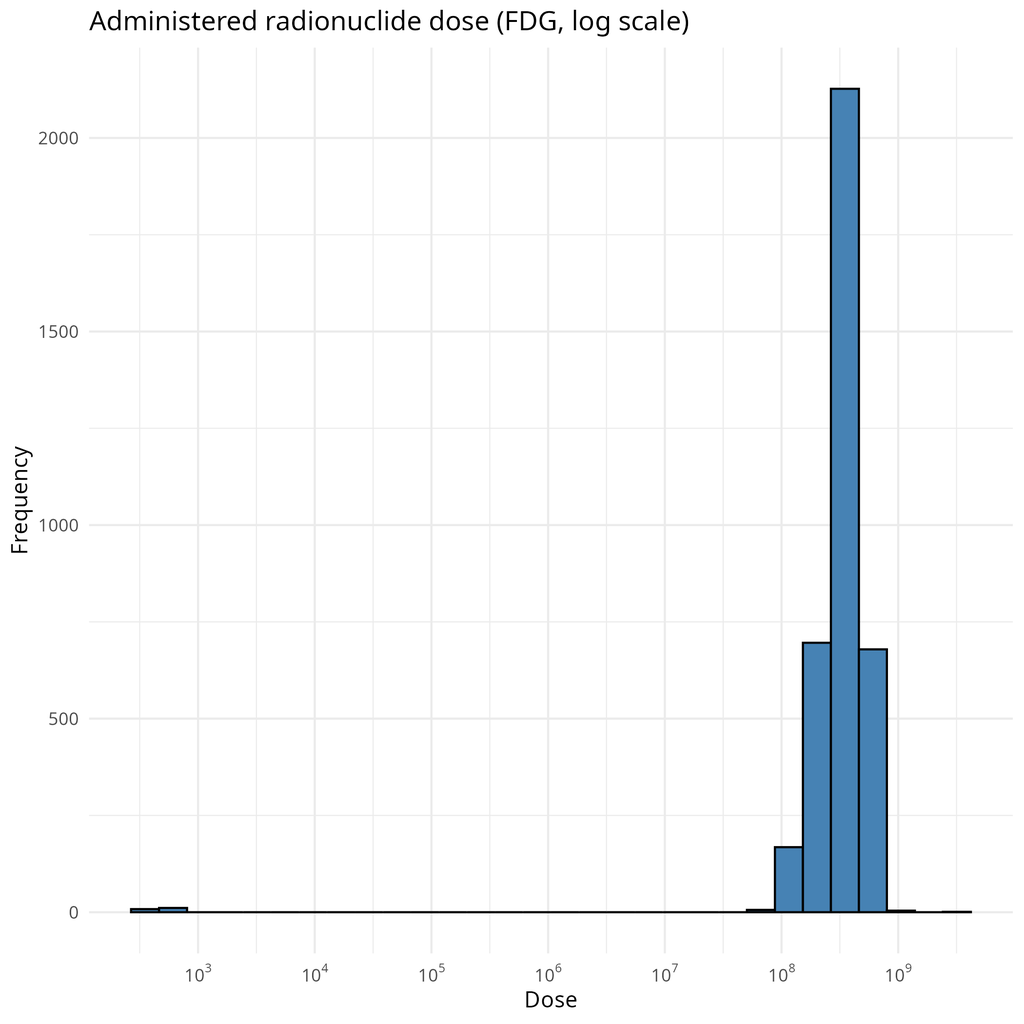

Fig. 2: Histogram of Radionuclide Total Dose (DICOM tag 0018,1074) values for FDG-PET series.

Regarding the dose correction, most series (N = 3474, 99.9 % were decay-corrected to the scan start time (Decay Correction = “START”), while there were no series decay-corrected to the administration time (Decay Correction = “ADMIN”). The remaining series were not decay corrected (Decay Correction = “NONE”, N = 2, 0.1 %). The majority of series (N = 2982, 80.1 %) contained more than one Acquisition Time (0008,0032) value.

Out of the series with Decay Correction = “START” and Units = “BMQL”, at least one frame lacked the value of Actual Frame Duration (0018,1242) in 26 series (0.7 %). However, in 23 of these series, the Manufacturer was GE, i.e., Actual Frame Duration would not be required for back-computation of the scan start time. As long as it was present, the Actual Frame Duration was always higher than zero. The attribute Frame Reference Time was present in all studied series and never lower than zero.

- Is the resulting time identical to the time component of the private scan start datetime (only applicable to Siemens and GE)?
- Does the value of the Decay Factor correspond to the time offset between the measurement time and the resulting scan start time (not applicable to Philips)?
- Is the resulting time consistent in all frames of the series, and is it not after Acquisition Time in any frame?

Additionally, regarding the measurement time, we evaluated:

- In non-decay-corrected images, to what time point do the voxel values correspond?

The date component is often excluded, as its associated issues are discussed in the following section.

##### Is the resulting scan start time identical to the time component of the private scan start datetime?

Both the QIBA strategy and the proposed strategy were applied and the resulting time was compared to the private scan start time. The private scan start time was not used for the scan start determination to simulate the scenario where this attribute is missing. In 498226 frames, both the proposed and the QIBA strategy would lead to the private scan start time. In 10496 frames, only the proposed strategy leads to this time, while in 1980 only the QIBA strategy does. In 4351 frames, none of these two strategies yields the private scan start time.

Across all series where the proposed strategy failed to lead to the private scan start time, the mean offset between the resulting and private scan start time was 318 s. The highest offset in the dataset was 1065 s. For the QIBA strategy, the mean offset was 7773 s and the maximum offset was 29682 s.

These data show that in our dataset, the proposed strategy (using Acquisition Time when identical to Series Time or back-computing scan start time) is more often concordant with the private scan start datetime than the QIBA strategy (using Series Time or earliest Acquisition Time). However, this is not fully reliable; therefore, the private scan start datetime should be used as the primary source.

##### In non-decay-corrected images, to what time point do the voxel values correspond?

The Decay Factor (0054,1321) attribute value corresponded to correction by the Frame Reference Time for 96.9 % frames within the Siemens series. In the GE series, it corresponded to the sum of Frame Reference Time and T<sub>ave</sub> in 99.0 % of frames. For the Philips series, the Decay Factor was always set to 1.0 and could not be used. In the CTI/CPS series, the Decay Factor corresponded to the Frame Reference Time only in 37.9 % of frames and to the sum of Frame Reference Time and T<sub>ave</sub> in 9.0 % of frames. However, in 93.3 % of frames, the Decay Factor corresponded to the offset between Series Time and Acquisition Time + T<sub>ave</sub>. All in all, the Decay Factor values indicate that for GE, Siemens, and CTI/CPS, the measured values (values before decay correction) most likely appeared at the time Acquisition Date/Time + T<sub>ave</sub> (= measurement time).

#### Digital reference object

Following DROs for decay correction alternatives were created:

- DRO_3_0 where dose is stored in MBq. Potential problems are:
  - the dose is considered in Bq.
- DRO_3_1 where Decay Correction is set to “ADMIN”. Potential problems are:
  - Decay Correction = “ADMIN” is not implemented.
- DRO_3_2_x where Decay Correction is set to “START”, private decay-correction datetime attributes are absent, and Series Date/Time is not equal to Acquisition Date/Time. Coming in four variations for vendors: DRO_3_2_0 (Siemens), DRO_3_2_1 (GE), DRO_3_2_2 (Philips), DRO_3_2_3 (Synthetic). Potential problems are:
  - dose is corrected to the Series Date/Time or to the Acquisition Date/Time;
  - the vendor-specific scan start datetime back-computation formulas are not implemented.
- DRO_3_3_x where Decay Correction is set to “START”, private decay-correction datetime attributes are present, coming in two variations for two vendors: DRO_3_3_0 (Siemens), DRO_3_3_1 (GE). Potential problems are:
  - the GE / Siemens private scan start datetime is not implemented.
  - the scan start datetime formulas are used instead of the private scan start datetime
- DRO_3_4_x where Decay Correction is set to “NONE” with multiple values of Acquisition Date/Time. Coming in four variations for vendors: DRO_3_4_0 (Siemens), DRO_3_4_1 (GE), DRO_3_4_2 (Philips), DRO_3_4_3 (Synthetic). Potential problems are:
  - Decay Correction = “NONE” is not implemented;
  - incorrect formula for voxel value decay correction or dose correction is used;
  - the real-world values and the administered dose are not corrected to the same time point.
- DRO_3_5_x where Decay Correction is set to “START”, private decay-correction datetime attributes are absent and Series Date/Time is equal to Acquisition Date/Time. Coming in four variations for vendors: DRO_3_5_0 (Siemens), DRO_3_5_1 (GE), DRO_3_5_2 (Philips), DRO_3_5_3 (Synthetic). Potential problems are:
  - Acquisition Date/Time is not used when Acquisition Date/Time = Series Date/Time.

The following DROs should yield an error in SUV<sub>bw</sub> computation:

- DRO_error_3_0 where Decay Correction is set to “START”, and Radionuclide Total Dose is absent
- DRO_error_3_1 where Decay Correction is set to “START”, and Radionuclide Total Dose has a non-positive value
- DRO_error_3_2 where Decay Correction is set to “START”, and Actual Frame Duration is absent (and the Manufacturer is not “GE”)

#### Recommendations

*If conversion from Bq/ml to SUV<sub>bw</sub> is required, the Radionuclide Total Dose (0018,1074) attribute should be present and have a positive, non-zero value; otherwise, SUV<sub>bw</sub> computation is not possible.*

Justification: Radionuclide Total Dose is required for conversion of Bq/ml to SUV<sub>bw</sub>.

*Radionuclide Total Dose (0018,1074) values higher than zero and lower than 10⁴ indicate storage in MBq and should be converted to Bq.*

Justification: Radionuclide Total Dose may be occasionally stored in MBq and must be converted to Bq. A threshold of 10⁴ was selected based on empirical observations that doses below/ equal to 10⁴ Bq or above 10⁴ MBq are highly unlikely.

*If conversion from Bq/ml to SUV<sub>bw</sub> is required, the Decay Correction (0054,1102) attribute must be present and have one of these values: “ADMIN”, “START”, “NONE”; otherwise, SUV<sub>bw</sub> computation is not possible.*

Justification: The decay correction method applied to the images must be known for conversion to SUV<sub>bw</sub>.

*In images where conversion from Bq/ml to SUV<sub>bw</sub> is required and Decay Correction (0054,1102) is set to “ADMIN”, dose correction is not required, and the SUV<sub>bw</sub> conversion is independent of the Manufacturer (0008,0070) attribute value.*

Justification: Frames with Decay Correction = “ADMIN” contain voxel values corrected to the time point when the radionuclide was administered, and its dose does not need to be corrected.

*If conversion from Bq/ml to SUV<sub>bw</sub> is required, and Decay Correction (0054,1102) is set to “START” or “NONE”, dose correction is required.*

Frames with Decay Correction = “START” or “NONE” store values at a different time point and the dose can be corrected to this time point. Another option is decay-correcting the images to the radionuclide administration time or correcting both the dose and image to another time point. However, the selected method has no effect on SUV<sub>bw</sub> and other methods are not explained in this manual.

*In images where dose correction is required and Decay Correction (0054,1102) is set to “START”, and the Manufacturer (0008,0070) attribute contains “SIEMENS”,* *the dose should be corrected to the datetime stored in the private scan start datetime (0071,1022) if it is present.*

Justification: The private scan start datetime is used by Siemens scanners for decay correction. Based on our observations, it represents the most reliable source of the scan start datetime. In contrast, Series Date/Time and the earliest Acquisition Date/Time within a series show lower reliability, as demonstrated above, and are therefore not recommended.

*In images where dose correction is required and Decay Correction (0054,1102) is set to “START”, and the Manufacturer (0008,0070) attribute contains “GE”,* *the dose should be corrected to the datetime stored in the private scan start datetime (0009,100D) if it is present.*

Justification: The private scan start datetime is used by GE scanners for decay correction. Based on our observations, it represents the most reliable source of the scan start datetime.

Justification: This option is used mainly for single-bed series, first bed positions of multi-bed series, and also accounts for the common pitfall of a constant Acquisition Date/Time and variable Frame Reference Times within some multi-bed series (observed in some GE and Siemens series).

*If dose correction is required and Decay Correction (0054,1102) is set to “START” and the previous three conditions are not met and the Manufacturer (0008,0070) attribute contains “GE”* *and the Acquisition Date (0008,0022) and Time (0008,0032) are present and the Frame Reference Time (0054,1300) has a non-negative value,* *the dose should be corrected to the time one Frame Reference Time (0054,1300) in seconds before the Acquisition Date (0008,0022) and Time (0008,0032).*

Justification: This option is used mainly for multi-bed series and is based on conformance statements, experiments, vendor responses, as well as indirect evidence, such as the values of the Decay Factor (0054,1321; GE) and GE private scan start datetime (0009,100D; GE).

*If dose correction is required and Decay Correction (0054,1102) is set to “START” and the previous four conditions are not met and the Acquisition Date (0008,0022) and Time (0008,0032) are present* *and the Frame Reference Time (0054,1300) has a non-negative value and the Actual Frame Duration (0018,1242) has a positive, non-zero value,* *the dose should be corrected to the time one Frame Reference Time (0054,1300) in seconds before the time the pixel values in the image occurred, i.e., Acquisition Date (0008,0022) and Time (0008,0032) + T<sub>ave</sub>.*

Justification: This option is used mainly for multi-bed series. For Siemens and Philips, it is based on conformance statements (Siemens), experiments (Siemens, Philips), vendor responses (Siemens), as well as indirect evidence, such as the values of the Decay Factor (0054,1321; Siemens) and Siemens private scan start datetime (0071,1022; Siemens). Furthermore, we recommended it for other vendors’ series as a fall-back strategy since it is included in the QIBA strategy and implied by the DICOM standards.

*If dose correction is required and Decay Correction (0054,1102) is set to “NONE”, the dose should be corrected to the measurement time, i.e., the sum of Acquisition Date (0008,0022), Acquisition Time (0008,0032), and the time of average activity within the Actual Frame Duration (0018,1242).*

Justification: For Siemens, Philips, and GE, the real-world values of non-decay-corrected images should always correspond to values at the Acquisition Date/Time + T<sub>ave</sub> (measurement time), so in one possible implementation, the dose can be corrected to this time point, which may differ between frames.

*Dose correction and all other computations shall be applied on a per-frame basis, using only attributes associated with the respective frame, and shall not depend on values from other frames.*

Justification: Each frame contains sufficient information for SUV<sub>bw</sub> computation. Scan-level approaches may introduce errors.

*The manufacturer names should be recognized regardless of capitalization or the presence of additional words or characters.*

Justification: Different variants of vendor names may appear in DICOM headers; for example, “GE MEDICAL SYSTEMS”, “GE MEDICAL SYSTEMS / MIMvista”, and “GEMS” all refer to GE.

*For cases where dose correction is required and the Manufacturer (0008,0070) attribute is absent or empty or not recognized as one of the vendors “SIEMENS”, “GE”, or “Philips”, the operator should receive a warning.*

Justification: Different vendors may implement the scan start datetime (the time to which real-world values are decay-corrected), Series Date/Time (whether it is identical to the scan start datetime), and measurement time (the time the original values occurred) differently. Currently, we lack sufficient real-world data for other vendors to verify the strategy for these vendors. Therefore, the general rules should be applied with caution.

Note: Other strategies, such as decay-correcting the real-world values to the administration datetime, are possible; however, not included in this manual.

## Administration time

#### Background

In cases where the administered dose has to be decay-corrected, the offset between the decay-correction reference datetime (scan start datetime or measurement datetime) and the radiotracer administration datetime has to be computed. The earlier was thoroughly described in the previous section. The latter - radiotracer administration time - can be extracted from the Radiopharmaceutical Information Sequence. However, this sequence originally did not store the calendar date information, as the attribute Radiopharmaceutical Start Time (0018,1072) was used, i.e., only administration time could be extracted. Later, it [was deprecated](https://dicom.nema.org/medical/dicom/current/output/chtml/part03/sect_c.8.9.2.html), and Radiopharmaceutical Start DateTime (0018,1078) was added. Furthermore, both Radiopharmaceutical Start DateTime and Acquisition Date (0008,0022) - which is often used for the decay-correction reference datetime determination - are often altered during post-processing, for example, due to anonymization.

Due to the aforementioned issues, the data have to be interpreted carefully, especially to recognize the following scenarios:

- PET scans with long-lived radionuclides, such as [Zirconium-89](https://doi.org/10.1186/s40644-022-00507-w), acquired one or more days after radiotracer administration (uptake time more than 24 hours) - can be only recognized by the dates;
- PET scans with short-lived radionuclides acquired on the day after radiotracer administration (uptake time spanning midnight) - can be recognized by the dates, or, alternatively, by the time component of the decay-correction datetime preceding the administration time;
- dynamic PET scans, where the time component of the decay-correction datetime may also precede the administration time (however, the administration occurs shortly after acquisition of the first frames).

#### Metadata analysis

Among the data examined, 1725 series (46.3 %) included only the Radiopharmaceutical Start Time without an associated date, 1981 series (53.2 %) included both values, and 15 series (0.4 %) included neither. There was only 1 series (0.0 %) in which only the Radiopharmaceutical Start DateTime was present, which may be because the other attribute was deprecated only recently.

Out of 1981 series with both attributes available, the Radiopharmaceutical Start Time and the time component of the Radiopharmaceutical Start DateTime differed in 24 series (1.2 %), but the difference was always between one and 60 seconds. In all these series, the Radiopharmaceutical Start Time seemed to be truncated to whole minutes.

Regarding the date component of the Radiopharmaceutical Start Datetime attribute, it differed from the Acquisition Date in 159 out of 1982 series (8.0 %) where both attributes were available. The most common offset was the Radiopharmaceutical Start Date one day after the Acquisition Date (101 cases, 5.1 %). The Radiopharmaceutical Start DateTime differed from the Series Date in 164 out of 1982 series (8.3 %). This demonstrates that these attributes are often subject to modification and therefore cannot be considered inherently reliable. There were no series that used a long-lived radionuclide.

There were 2 series with the Radiopharmaceutical Start Date one day before the Acquisition Date. However, the administration time preceded the acquisition times by 63 and 66 minutes, respectively, so the acquisition most likely occurred on the same day as radiotracer administration. 37 series contained frames with Acquisition Time before Radiopharmaceutical Start Time. All were dynamic scans from the “ACRIN-FLT-BREAST” collection. The highest time offset between Acquisition Time and Radiopharmaceutical Start Time was 166 seconds.

#### Digital reference object

Following objects were created:

- DRO_4_0 where only the Radiopharmaceutical Start DateTime is present and the Radiopharmaceutical Start Time is absent. Potential problems are:
  - the Radiopharmaceutical Start Time is required.
- DRO_4_1 where only the Radiopharmaceutical Start Time is present, and the Radiopharmaceutical Start DateTime is absent. Potential problems are:
  - the Radiopharmaceutical Start DateTime is required.
- DRO_4_2 with radiotracer administered before midnight and scanned after midnight. The Radiopharmaceutical Start Datetime is absent. Potential problems are:
  - the Radiopharmaceutical Start Time and the time component of the decay-correction reference time are not compared.
- DRO_4_3 with radiotracer administered before midnight and scanned after midnight. The Radiopharmaceutical Start Datetime is present. Potential problems are:
  - date components of Radiopharmaceutical Start DateTime and the decay-correction reference datetime are not compared.
- DRO_4_4 with radiotracer administered before midnight and scanned after midnight. The Radiopharmaceutical Start Datetime is present but the Acquisition Date was anonymized. Potential problems are:
  - the Radiopharmaceutical Start DateTime and the decay-correction reference datetime offset is used even when one of the dates is changed or when both dates are shifted by different time offsets.
- DRO_4_5 with a long-lived radionuclide - the uptake time spans more than one day. Potential problems are:
  - the Radiopharmaceutical Start DateTime and decay-correction reference datetime are not compared;
  - half-life is not extracted correctly from the Radionuclide Half Life attribute;
  - radionuclide half-life is not considered within the dose decay correction.

The following DROs should yield an error in SUV<sub>bw</sub> computation:

- DRO_error_4_0 where both Radiopharmaceutical Start DateTime and Radiopharmaceutical Start Time are absent.
- DRO_error_4_1 with a long-lived radionuclide - the uptake time spans more than one day, and the Radiopharmaceutical Start DateTime is absent.
- DRO_error_4_2 with a long-lived radionuclide - the uptake time spans more than one day, and the Radiopharmaceutical Start DateTime was anonymized.

#### Recommendations

*If Radiopharmaceutical Start DateTime (0018,1078) is available and the time offset between the decay-correction reference datetime* *and Radiopharmaceutical Start DateTime (0018,1078) is higher or equal to -3,600 s and shorter than twice the Radionuclide Half Life (0018,1075),* *the attribute Radiopharmaceutical Start DateTime (0018,1078) should be considered as the datetime the radiotracer was administered.*

Justification: Knowing the dates is essential for determining the time offset for dose decay correction. However, one or both datetimes are often modified during post-processing. This situation represents the scenario where the dates were most likely either not modified or shifted by the same time offset. For that, we expect the decay-correction datetime (scan start or measurement time) to be not longer than one hour before and earlier than two radionuclide half-lifes after radiotracer administration. The thresholds were selected arbitrarily: since the uptake times vary based on radionuclide half-life and may span several days for long-lived radionuclides, an arbitrary threshold of two half-lifes was selected. The one-hour threshold was described in the previous section.

*If Radiopharmaceutical Start DateTime (0018,1078) is available and the time offset between the decay-correction reference datetime* *and Radiopharmaceutical Start DateTime (0018,1078) is lower than -3,600 s or longer or equal to twice the Radionuclide Half Life (0018,1075),* *SUV<sub>bw</sub> can only be computed if the Radionuclide Half Life (0018,1075) is shorter than 41,400 s, and the operator should receive a warning.* *In that case, the date component of the decay-correction reference datetime should be considered as the date the radiotracer was administered,* *while the time component of the Radiopharmaceutical Start DateTime (0018,1078) should be considered as the time the radiotracer was administered.* *If the time offset between the time components of the decay-correction datetime and Radiopharmaceutical Start DateTime (0018,1078) is lower than -3,600s, 24 hours should be subtracted from the resulting datetime* *and the operator should receive a warning.*

Justification: This recommendation covers the scenario when the offset between Radiopharmaceutical Start DateTime and decay-correction datetime indicates one of the dates is wrong. In that case, only the same dates should be used as long as a short-lived radionuclide was used, with an arbitrary half-life threshold of 41,400 s (11.5 hours). For radionuclides with longer half-lifes, an uptake time of more than 23 hours can be expected; therefore, an administration date correctly encoded in the DICOM metadata is necessary. Finally, the last sentence covers the situations where a short-lived radionuclide was used but the uptake time spans midnight, indicated by a decay-correction time more than one hour before the administration time when the dates are unknown or unreliable.

*If Radiopharmaceutical Start DateTime (0018,1078) is unavailable and the Radiopharmaceutical Start Time (0018,1072) is present,* *SUV<sub>bw</sub> can only be computed if the Radionuclide Half Life (0018,1075) is shorter than 41,400 s, and the operator should receive a warning.* *In that case, the date component of the decay-correction reference datetime should be considered as the date the radiotracer was administered,* *while the Radiopharmaceutical Start Time (0018,1072) should be considered as the time the radiotracer was administered.* *If the time offset between the time component of the decay-correction datetime and Radiopharmaceutical Start Time (0018,1072) is lower than -3,600s, 24 hours should be subtracted from the resulting datetime,* *and the operator should receive a warning.*

Justification: Analogically to the previous recommendation, Radiopharmaceutical Start Time can be used for short-lived radionuclides where the date is expected to be the same as the date of the decay-correction reference datetime, or, in rare cases, the day before (but less than 23 hours before).

*If the dose correction is required and both Radiopharmaceutical Start DateTime (0018,1078) and Radiopharmaceutical Start Time (0018,1072) are absent or empty, SUV<sub>bw</sub> computation is not possible.*

Justification: The administration datetime is required in all cases where dose correction is required.

## Radionuclide half-life

#### Background

Although Fluorine-18 (F-18) is the predominant radionuclide in clinical PET imaging, other radionuclides are also used. The radionuclide information is reflected in the Radionuclide Half Life (0018,1075) attribute, which defines the physical half-life in seconds. The radionuclide information may also be encoded in other parts of the DICOM metadata, such as the Radiopharmaceutical (0018,0031) attribute or within the Radionuclide Code Sequence (0054,0300).

#### Metadata analysis

All series had the Radionuclide half-life provided, and it always had a positive value. Most series used F-18 as the radionuclide (Table 3).

Table 3: Unique values of RadionuclideHalfLife (0018,1075); half-life values were truncated.

| RadionuclideHalfLife (s) | Freq | Perc | Corresponds to |
| --- | --- | --- | --- |
| 1223 | 2 | 0.1 % | C-11 |
| 6586 | 2324 | 62.4 % | F-18 |
| 6588 | 1396 | 37.5 % | F-18 |

#### Digital reference object

To check that radionuclide half-life is taken into account when SUV<sub>bw</sub> is computed, the following DROs were constructed:

- DRO_5_0 with Ga-68 used as the radionuclide. Potential problems are:
  - radionuclide half-life is not extracted correctly from RadionuclideHalfLife;
  - radionuclide half-life is not considered within the dose decay correction.

The following DROs should yield an error in SUV<sub>bw</sub> computation:

- DRO_error_5_0 where Radionuclide Half Life is absent.

#### Recommendations

*In images where dose correction is required, the Radionuclide Half Life (0018,1075) attribute must be present and have a positive, non-zero value;* *otherwise, SUV<sub>bw</sub> computation is not possible.*

Justification: The Radionuclide Half Life is used for dose correction.

## Computing SUV<sub>bw</sub> in other SOP classes

### Enhanced PET Image Storage SOP Class

#### Background

The Enhanced PET Image Storage SOP Class can be recognized by the SOP Class UID (0008,0016) value “1.2.840.10008.5.1.4.1.1.130”. This format solves many of the aforementioned issues with the Positron Emission Tomography SOP Class, but also poses a new challenge to medical image analysis tools. The main differences relevant to SUV<sub>bw</sub> computation include:

- Functional groups: Frame-specific metadata are stored within Per-Frame Functional Groups Sequence (5200,9230) with each item corresponding to one frame. Shared Functional Groups define default values for all frames, while Per-frame Functional Groups override them where specified.
- Voxel values: typically stored as a multi-frame (multi-dimensional) object.
- Rescaling: stored within the Real World Value Mapping Sequence (0040,9096) as attributes Real World Value Slope (0040,9225) and Real World Value Intercept (0040,9224). Alternatively, rescaling may be done using the attribute Real World Value LUT Data (0040,9212).
- Units: stored within the Measurement Units Code Sequence (0040, 08EA). In one possible implementation, units are encoded using the Context Identifier (CID) 84 and 85 - e.g., Code Value (0008,0100) “Bq/ml” (UCUM designator, CID 84 v. 20170914) corresponds to Units (0054,1001) “BQML”. Units g/ml are followed by the SUV<sub>bw</sub> type, e.g., “g/ml{SUVbw}” (UCUM designator, CID 85 v.20161106) corresponds to Units (0054,1001) “GML” with SUV Type (0054,1006) “BW”.
- Dose: decay-corrected images are recognized by the value “YES” of the Decay Corrected (0018,9758) attribute. The decay-correction reference datetime is stored in the attribute Decay Correction DateTime (0018,9701). Images that are not decay-corrected (Decay Corrected (0018,9758) = “NO”) show values at the Frame Reference DateTime (0018,9151), which can be used as decay-correction reference datetime.
- Administration time: only stored as Radiopharmaceutical Start DateTime (0018,1078).

#### Metadata analysis

There were no series of this SOP class among the analyzed files.

#### Digital reference object

To verify that the Enhanced PET SOP Class is quantified correctly, the following DROs were constructed:

- DRO_7_0_0 default DRO of the Enhanced PET SOP class. Potential problems are:
  - Enhanced PET SOP Class is not implemented
  - stored voxel values or units are not interpreted correctly
- DRO_7_1_0 with multiple values of Real World Value Slope Slope. Potential problems are:
  - per-frame rescale slope is not applied correctly
- DRO_7_2_0 with units corresponding to g/ml (SUV<sub>bw</sub>). Potential problems are:
  - units code is not interpreted correctly
- DRO_7_3_0 with Decay Corrected set to “YES” and series and acquisition datetimes after Decay Correction DateTime. Potential problems are:
  - Decay Correction DateTime is not used as decay-correction reference time (scan start time) for dose correction
- DRO_7_3_1 with Decay Corrected set to “NO”. Potential problems are:
  - Frame Reference Datetime is not used as the decay-correction reference time (measurement time) for dose correction

#### Recommendations

*Medical image analysis software should be able to read and correctly quantify PET images of the Enhanced PET SOP Class.*

*At least one Real World Value Mapping Sequence (0040,9096) containing sufficient information for conversion to SUV or Bq/ml must be present;* *otherwise, SUV<sub>bw</sub> computation is not possible.* *The information consists of rescaling data, i.e., the Real World Value Slope (0040,9225) and Real World Value Intercept (0040,9224) or the Real World Value LUT Data (0040,9212)* *and the physical units, specified in the Measurement Units Code Sequence (0040, 08EA).*

Justification: Typically, the Real World Value Slope (0040,9225) and Real World Value Intercept (0040,9224) are present and can be applied analogously as the Rescale Slope and Rescale Intercept in the Positron Emission Tomography SOP Class

*If a Real World Value Mapping Sequence (0040,9096) containing sufficient data for conversion to SUV<sub>bw</sub> is present, the values should be converted to SUV<sub>bw</sub> using this sequence.* *If no Real World Value Mapping Sequence (0040,9096) containing sufficient data for conversion to SUV<sub>bw</sub> is present* *and a Real World Value Mapping Sequence (0040,9096) containing sufficient data for conversion to another SUV type is present, the values should be converted to this SUV type using this sequence.*

*If no Real World Value Mapping Sequence (0040,9096) containing sufficient data for conversion to SUV<sub>bw</sub> or another SUV type is present* *and a Real World Value Mapping Sequence (0040,9096) containing sufficient data for conversion to another Bq/ml type is present, the values should be converted to Bq/ml using this sequence,* *and dose correction are required.*

Justification: Unit code can be stored either in (0008,0100) Code Value, (0008,0119) Long Code Value, or (0008,0120) URN Code Value. Multiple instances of Real World Value Mapping Sequence may be present and the one leading to SUV<sub>bw</sub> or another SUV type should be prioritized.

*If no Real World Value Mapping Sequence (0040,9096) containing sufficient information for conversion to SUV or Bq/ml is present,* *and the Rescale Type (0028, 1054) is set to a BQML, GML, or CM2ML, convert the stored values to the corresponding physical units using* *the Rescale Intercept (0028,1052) and Rescale Slope (0028,1053) from the Pixel Value Transformation Sequence (0028,9145).*

Justification: An alternative that is similar to the Positron Emission Tomography SOP Class. Rescale Type (0028, 1054) could potentially be used to indicate the physical units of the stored values. However, it is a fallback option as the attribute is supposed to be unspecified for PET (“US”).

*If the conversion between SUV types is required, the Patient’s Weight (0010,1030) and the Patient’s Size (0010,1020) must have a positive, non-zero value; otherwise, SUV<sub>bw</sub> computation is not possible.* *Furthermore, if the sex of the patient is required to be known for the calculation, the Patient’s Sex (0010,1040) must have one of the values “M”, “F”, or “O”; otherwise, SUV<sub>bw</sub> computation is not possible.* *The conversion between SUV types should be done using the aforementioned conversion formulas.*

*The corresponding conversion has to be applied to all stored voxel values within a frame.* *If no Real World Value Mapping Sequence (0040,9096) or Pixel Value Transformation Sequence (0028,9145) containing sufficient information for conversion to SUV or Bq/ml is present,* *SUV<sub>bw</sub> computation is not possible.*

*If dose correction is required, the attribute Patient’s Weight (0010,1030) must be present and have a positive, non-zero value. Otherwise, SUV<sub>bw</sub> cannot be computed.* *The Patient’s Weight (0010,1030) values equal to or greater than 1000 should be interpreted as grams, while values lower than 1000 should be interpreted as kilograms.*

Justification: Analogous to the Positron Emission Tomography SOP Class.

*If dose correction is required, the Decay Corrected (0018,9758) attribute must be present and have one of the values “YES” or “NO”; otherwise, SUV<sub>bw</sub> computation is not possible.* *If dose correction is required and Decay Corrected (0018,9758) is “YES”, Decay Correction DateTime (0018,9701) must be present; otherwise, SUV<sub>bw</sub> computation is not possible.* *The dose should be corrected to this time.*

Justification: These attributes simplify the determination of the decay-correction reference time. The decay-correction reference datetime for decay-corrected images is stored in this attribute and allows for computing SUV values independent of vendor.

*If dose correction is required and Decay Corrected (0018,9758) is “NO” and Frame Reference DateTime (0018,9151) is present, this datetime corresponds to the time at which the average activity occurred (measurement time).* *If dose correction is required and Decay Corrected (0018,9758) is “NO” and Frame Reference DateTime (0018,9151) is absent or empty and Frame Acquisition Datetime (0018,9074) is present and Frame Acquisition Duration (0018,9220) has a non-negative value,* *the dose should be corrected to the measurement time, i.e., the sum of Frame Acquisition Datetime (0018,9074) and the time of average activity within the Frame Acquisition Duration (0018,9220).* *Otherwise, SUV<sub>bw</sub> computation is not possible.*

Justification: Based on DICOM definition.

*If Radiopharmaceutical Start DateTime (0018,1078) is present and the time offset between the decay-correction reference datetime and Radiopharmaceutical Start DateTime (0018,1078)* *is higher or equal to -3,600 s and shorter than twice the Radionuclide Half Life (0018,1075),* *the administration datetime can be extracted from the attributes Radiopharmaceutical Start DateTime (0018,1078).* *If Radiopharmaceutical Start DateTime (0018,1078) is present and the time offset between the decay-correction reference datetime and Radiopharmaceutical Start DateTime (0018,1078)* *is lower than -3,600 s or longer or equal to twice the Radionuclide Half Life (0018,1075), SUV<sub>bw</sub> can only be computed if the Radionuclide Half Life (0018,1075) is shorter than 41,400s.* *In that case, the administration datetime should be created by a combination of the date component of the decay-correction datetime and the time component of the Radiopharmaceutical Start DateTime (0018,1078).* *If the time offset between the time components of the decay-correction datetime and Radiopharmaceutical Start DateTime is lower than -3,600s, subtract one day from the administration datetime.* *If Radiopharmaceutical Start DateTime (0018,1078) is absent, SUV<sub>bw</sub> computation is not possible.*

Justification: Analogous to the Positron Emission Tomography SOP Class, however, Radiopharmaceutical Start Time (0018,1072) is always absent.

*In images where dose correction is required, the Radionuclide Half Life (0018,1075) attribute must be present and have a positive, non-zero value; otherwise, SUV<sub>bw</sub> computation is not possible.*

Justification: Analogous to the Positron Emission Tomography SOP Class.

### Legacy Converted Enhanced PET Image Storage

#### Background

The SOP Class UID (0008,0016) value “1.2.840.10008.5.1.4.1.1.128.1” corresponds to the Legacy Converted Enhanced PET Image Storage. Images of this class are generated from the Positron Emission Tomography SOP Class in order to increase complementarity with the Enhanced PET SOP class and combine the elements of these two classes.

#### Metadata analysis

There were no series of this SOP class among the analyzed files.

#### Digital reference object

There are currently no digital reference objects of this class.

#### Recommendations

*Medical image analysis software should be able to read and quantify correctly PET images of the Legacy Converted Enhanced PET SOP Class.* *The same recommendations apply as for the Enhanced PET SOP Class. In case the information required for SUV<sub>bw</sub> computation is missing, attributes from the Positron Emission Tomography SOP Class should be used.*

## Computing other SUV types

Other commonly used SUV types, such as SUV<sub>lbm</sub>, SUV<sub>bsa</sub>, and SUV<sub>ibw</sub>, can be computed analogously by replacing body weight with the corresponding normalization factors, as described in the section “Units”.

E.g., to convert SUV<sub>bw</sub> to another SUV type, the original SUV can be multiplied by the corresponding factor and divided by the patient’s weight:

$$\text{SUV}_{lbmjames128} =
\frac{\text{SUV}_{bw} \, \text{LBM}_{james128} \,
10^{3}}{W}$$

$$\text{SUV}_{lbmjanma} =
\frac{\text{SUV}_{bw} \, \text{LBM}_{janma} \, 10^{3}}{W}$$

$$\text{SUV}_{ibw} =
\frac{\text{SUV}_{bw} \, \text{IBW} \, 10^{3}}{W}$$

$$\text{SUV}_{bsa} =
\frac{\text{SUV}_{bw} \, \text{BSA} \, 10^{4}}{W}$$

Note that computing these SUV types may change which attributes are required. As an example, Patient’s Size (0010,1020) is required for all these SUV types, while Patient’s Sex (0010,1040) is only required for SUV<sub>lbmjames128</sub>, SUV<sub>lbmjanma</sub>, and SUV<sub>ibw</sub>, except for cases when the real-world values already correspond to this SUV type. In contrast, Patient’s Weight (0010,1030) is not required to compute SUV<sub>ibw</sub>.

# Discussion (tbd)

In the past, efforts have been made to standardize SUV computation, most notably by the [Quantitative Imaging Biomarkers Alliance (QIBA)](https://qibawiki.rsna.org/index.php/Main_Page). Furthermore, [digital reference objects for SUV computation](https://depts.washington.edu/petctdro/index.html) have been developed; however, these only evaluate the most common scenario with Units = “BQML” and Decay Correction = “START”.

The present manual, together with the extended set of DROs, broadens the scope to cover multiple acquisition and metadata scenarios and can therefore support consistent and reproducible implementation of SUV computation across software platforms and institutions – an aspect that is particularly critical in multi-center studies. Additionally, a precise specification of the conditions and methodology for SUV computation will enable fully automated pipelines for both research and clinical purposes.

As a limitation, the results may be biased by the data that we had at hand. Furthermore, the analysis and resulting recommendations are partially restricted to three vendors, as data from other vendors were sparse or unavailable both in the metadata analysis and in the literature. We contacted these vendors; however, no response has been received to date.

# Supplementary material

Suppl. Table 1: DICOM attributes scanned in the metadata analysis.

| DICOMTag | Attribute | Vendor-specific |
| --- | --- | --- |
| 0008,0021 | SeriesDate | No |
| 0008,0022 | AcquisitionDate | No |
| 0008,002A | AcquisitionDateTime | No |
| 0008,0031 | SeriesTime | No |
| 0008,0032 | AcquisitionTime | No |
| 0008,0060 | Modality | No |
| 0008,0070 | Manufacturer | No |
| 0008,103E | SeriesDescription | No |
| 0008,1090 | ManufacturerModelName | No |
| 0009,100D | GEDecayCorrectionDateTime | GE |
| 0009,103B | GEAdministrationDateTime | GE |
| 0010,0010 | PatientName | No |
| 0010,0020 | PatientID | No |
| 0010,0040 | PatientSex | No |
| 0010,1020 | PatientSize | No |
| 0010,1030 | PatientWeight | No |
| 0018,1072 | RadiopharmaceuticalStartTime | No |
| 0018,1074 | RadionuclideTotalDose | No |
| 0018,1075 | RadiotracerHalfLifeTime | No |
| 0018,1078 | RadiopharmaceuticalStartDateTime | No |
| 0018,1242 | ActualFrameDuration | No |
| 0018,9701 | DecayCorrectionDateTime | No |
| 0028,1052 | RescaleIntercept | No |
| 0028,1053 | RescaleSlope | No |
| 0054,0300 | RadionuclideCodeSequence | No |
| 0054,1000 | SeriesType | No |
| 0054,1001 | Units | No |
| 0054,1006 | SUVType | No |
| 0054,1102 | DecayCorrection | No |
| 0054,1300 | FrameReferenceTime | No |
| 0054,1321 | DecayFactor | No |
| 0054,1322 | DoseCalibrationFactor | No |
| 0071,1022 | SiemensDecayCorrectionDateTime | Siemens |
| 7053,1000 | PhilipsSUVScaleFactor | Philips |
| 7053,1009 | PhilipsActivityConcentrationScaleFactor | Philips |

Suppl. Table 2: DICOM attributes required for SUV<sub>bw</sub> computation in images from the Positron Emission Tomography Image Storage SOP class. Note that some of them are only required conditionally, depending on the combination of values of other attributes.

| DICOMTag | AttributeName | Type | VR | Note |
| --- | --- | --- | --- | --- |
| 0008,0016 | SOP Class UID | 1 | UI | Should be “1.2.840.10008.5.1.4.1.1.128” |
| 0008,0021 | Series Date | 1 | DA |  |
| 0008,0022 | Acquisition Date | 2 | DA |  |
| 0008,0031 | Series Time | 1 | TM |  |
| 0008,0032 | Acquisition Time | 2 | DA |  |
| 0008,0060 | Modality | 1 | CS | Should be “PT” |
| 0008,0070 | Manufacturer | 2 | LO |  |
| 0009,100D | GE Private Scan Start DateTime | 3 | DT | Private – name, type, and VR not defined by DICOM standards |
| 0010,0040 | Patient Sex | 2 | CS | Possible values: “M”, “F”, or “O” |
| 0010,1020 | Patient Size | 3 | DS | Standard unit: m; should be >0 |
| 0010,1030 | Patient Weight | 3 | DS | Standard unit: kg; should be >0 |
| 0018,1072 | Radiopharmaceutical Start Time | 3 | TM |  |
| 0018,1074 | Radionuclide Total Dose | 3 | DS | Standard unit: Bq; should be >0 |
| 0018,1075 | Radiotracer Half Life Time | 3 | DS | Standard unit: sec; should be >0 |
| 0018,1078 | Radiopharmaceutical Start Date Time | 3 | DT |  |
| 0018,1242 | Actual Frame Duration | 2 | IS | Standard unit: msec; should be >0 |
| 0028,1052 | Rescale Intercept | 1 | DS |  |
| 0028,1053 | Rescale Slope | 1 | DS |  |
| 0054,1001 | Units | 1 | CS | Possible values: “BQML”, “GML”, “CM2ML”, “CNTS” |
| 0054,1006 | SUV Type | 3 | CS | Possible values: “BW”, “LBM”, “LBMJAMES128”, “LBMJANMA”, “IBW”, or “BSA” |
| 0054,1102 | Decay Correction | 1 | CS | Possible values: “ADMIN”, “START”, “NONE” |
| 0054,1300 | Frame Reference Time | 1 | DS | Standard unit: msec; should be >=0 |
| 0071,1022 | Siemens Private Scan Start DateTime | 3 | DT | Private – name, type, and VR not defined by DICOM standards |
| 7053,1000 | Philips SUV Scale Factor | 3 | DS | Private – name, type, and VR not defined by DICOM standards |
| 7053,1009 | Philips Activity Concentration Scale Factor | 3 | DS | Private – name, type, and VR not defined by DICOM standards |
| 7fe0,0010 | Pixel Data | 1C | OB/OW | Standardly a 2-dimensional object |

[figure not shown]

Suppl. Table 3: DICOM attributes required for SUV<sub>bw</sub> computation in images from the Enhanced PET SOP Image Storage class. Note that some of them are only required conditionally, depending on the combination of values of other attributes.

| DICOMTag | AttributeName | Type | VR | Note |
| --- | --- | --- | --- | --- |
| 0008,0016 | SOP Class UID | 1 | UI | Should be “1.2.840.10008.5.1.4.1.1.130” |
| 0008,0060 | Modality | 1 | CS | Should be “PT” |
| 0010,0040 | Patient Sex | 2 | CS | Possible values: “M”, “F”, or “O” |
| 0010,1020 | Patient Size | 3 | DS | Standard unit: m; should be >0 |
| 0010,1030 | Patient Weight | 3 | DS | Standard unit: kg; should be >0 |
| 0018,1074 | Radionuclide Total Dose | 2 | DS | Standard unit: Bq; should be >0 |
| 0018,1075 | Radiotracer Half Life | 1 | DS | Standard unit: sec; should be >0 |
| 0018,1078 | Radiopharmaceutical Start Date Time | 1 | DT |  |
| 7fe0,0010 | Pixel Data | 1C | OB/OW | Standardly a 3-dimensional object |
| 0040,9224 | Real World Value Intercept | 1C | FD | Preferably from the per-frame functional group |
| 0040,9225 | Real World Value Slope | 1C | FD | Preferably from the per-frame functional group |
| 0018,9758 | Decay Corrected | 1C | CS | Possible values: “YES” or “NO” |
| 0018,9701 | Decay Correction Datetime | 1C | DT |  |
| 0018,9220 | Frame Acquisition Duration | 1C | FD | Standard unit: msec; should be >0; Preferably from the per-frame functional group |
| 0018,9074 | Frame Acquisition Datetime | 1C | DT | Preferably from the per-frame functional group |
| 0018,9151 | Frame Reference Datetime | 1C | DT | Preferably from the per-frame functional group |
| 0040,08EA | Measurement Units Code Sequence | 1 | SQ | Unit stored either as Code Value, Long Code Value, or URN Code Value. Should correspond to Bq/ml, g/ml, or cm2/ml. |

[figure not shown]

Suppl. Fig. 1: Flowchart showing the recommended SUV<sub>bw</sub> computation strategy for the Enhanced PET Image Storage SOP class (working vesion).

Suppl. Table 4: List of created DROs to verify SUV<sub>bw</sub> computation.

| Section | ID | Description |
| --- | --- | --- |
| default | DRO_0_0 | Default DRO of the Positron Emission Tomography Image Storage SOP class |
| rescale | DRO_1_0 | multiple values Rescale Slope |
| units | DRO_2_0 | Units are “GML” corresponding to SUVbw |
| units | DRO_2_1_0 | Units are “GML” with Patient’s Sex is “M” corresponding to SUVlbmjames128 |
| units | DRO_2_1_1 | Units are “GML” with Patient’s Sex is “F” corresponding to SUVlbmjames128 |
| units | DRO_2_1_2 | Units are “GML” with Patient’s Sex is “O” corresponding to SUVlbmjames128 |
| units | DRO_2_2_0 | Units are “GML” with Patient’s Sex is “M” corresponding to SUVibw |
| units | DRO_2_2_1 | Units are “GML” with Patient’s Sex is “F” corresponding to SUVibw |
| units | DRO_2_2_2 | Units are “GML” with Patient’s Sex is “O” corresponding to SUVibw |
| units | DRO_2_3 | Units are “CM2ML” corresponding to SUVbsa |
| units | DRO_2_4 | Units are “CNTS” using Philips SUV scale factor |
| units | DRO_2_5 | Units are “CNTS” using Philips activity scale factor |
| units | DRO_2_6_0 | Units are “GML” with Patient’s Sex is “M” corresponding to SUVlbmjanma |
| units | DRO_2_6_1 | Units are “GML” with Patient’s Sex is “F” corresponding to SUVlbmjanma |
| units | DRO_2_6_2 | Units are “GML” with Patient’s Sex is “O” corresponding to SUVlbmjanma |
| dose | DRO_3_0 | Dose in MBq |
| dose | DRO_3_1 | Decay Correction is “ADMIN” |
| dose | DRO_3_2_0 | Decay Correction is “START” but Series Date/Time after Acquisition Date/Time SIEMENS |
| dose | DRO_3_2_1 | Decay Correction is “START” but Series Date/Time after Acquisition Date/Time GE |
| dose | DRO_3_2_2 | Decay Correction is “START” but Series Date/Time after Acquisition Date/Time PHILIPS |
| dose | DRO_3_2_3 | Decay Correction is “START” but Series Date/Time after Acquisition Date/Time SYNTHETIC |
| dose | DRO_3_3_0 | Decay Correction is “START” but Series Date/Time after Acquisition Date/Time and private scan start datetime present SIEMENS |
| dose | DRO_3_3_1 | Decay Correction is “START” but Series Date/Time after Acquisition Date/Time and private scan start datetime present GE |
| dose | DRO_3_4_0 | Decay Correction is “NONE” and multiple values Acquisition Date/Time SIEMENS |
| dose | DRO_3_4_1 | Decay Correction is “NONE” and multiple values Acquisition Date/Time GE |
| dose | DRO_3_4_2 | Decay Correction is “NONE” and multiple values Acquisition Date/Time PHILIPS and Units are CNTS |
| dose | DRO_3_4_3 | Decay Correction is “NONE” and multiple values Acquisition Date/Time SYNTHETIC |
| dose | DRO_3_5_0 | Decay Correction is “START” but Series Date/Time equal to Acquisition Date/Time SIEMENS |
| dose | DRO_3_5_1 | Decay Correction is “START” but Series Date/Time equal to Acquisition Date/Time GE |
| dose | DRO_3_5_2 | Decay Correction is “START” but Series Date/Time equal to Acquisition Date/Time PHILIPS |
| dose | DRO_3_5_3 | Decay Correction is “START” but Series Date/Time equal to Acquisition Date/Time SYNTHETIC |
| admintime | DRO_4_0 | Radiopharmaceutical Start DateTime present and Radiopharmaceutical Start Time absent |
| admintime | DRO_4_1 | Radiopharmaceutical Start Time present and Radiopharmaceutical Start DateTime absent |
| admintime | DRO_4_2 | Uptake time sparing midnight and Radiopharmaceutical Start DateTime absent |
| admintime | DRO_4_3 | Uptake time sparing midnight and Radiopharmaceutical Start DateTime present |
| admintime | DRO_4_4 | Uptake time sparing midnight and anonymized Acquisiiton Date |
| admintime | DRO_4_5 | Radionuclide Zr89 and uptake time more than 24 hours and Radiopharmaceutical Start DateTime present |
| halflife | DRO_5_0 | Radionuclide Ga68 |
| enhanced | DRO_7_0_0 | Default DRO of the Enhaced PET Image Storage SOP class |
| enhanced | DRO_7_1_0 | Enhanced PET and multiple values Rescale Slope |
| enhanced | DRO_7_2_0 | Enhanced PET and Units are “GML” corresponding to SUVbw |
| enhanced | DRO_7_3_0 | Enhanced PET and Series Date/Time after Decay Correction Datetime |
| enhanced | DRO_7_3_1 | Enhanced PET and DecayCorrected = “NO” and multiple values Frame Reference DateTime |
| units | DRO_error_2_0 | Units are “BQML” and Patient’s Weight is missing |
| units | DRO_error_2_1 | Units are “BQML” and Patient’s Weight is 0 |
| units | DRO_error_2_2 | Units are “GML” corresponding to SUVibw and Patient’s Sex is absent |
| units | DRO_error_2_3 | Units are “GML” corresponding to SUVibw and Patient’s Sex has other value |
| units | DRO_error_2_4 | Units are “GML” corresponding to SUVibw and Patient’s Size is absent |
| units | DRO_error_2_5 | Units are “GML” corresponding to SUVibw and Patient’s Size is 0 |
| units | DRO_error_2_6 | Units are “CNTS” and both activity scale factor and SUV scale factor are absent |
| units | DRO_error_2_7 | Units are “PROPCNTS” |
| dose | DRO_error_3_0 | Radionuclide Total Dose is absent |
| dose | DRO_error_3_1 | Radionuclide Total Dose is negative |
| dose | DRO_error_3_2 | Actual Frame Duration is absent and not GE |
| admintime | DRO_error_4_0 | Both Radiopharmaceutical Start Time and Radiopharmaceutical Start DateTime are absent |
| admintime | DRO_error_4_1 | Uptake time more than 24 hours and Radiopharmaceutcial Start DateTime is absent |
| admintime | DRO_error_4_2 | Uptake time more than 24 hours and Radiopharmaceutcial Start DateTime is anonymized |
| halflife | DRO_error_5_0 | Radionuclide Half Life is absent |